# Unidades: o que caracteriza as que vão melhor

Bolsa PDI 2026 (TO 212.435) · reunião de acompanhamento · C5

Bragatte, M.A.S

2026-07-27

## Os dois pedidos de 03/06, hoje

| Pedido da equipe de pesquisa | Status |
| --- | --- |
| **2 · Encaminhamentos** — especialidades por CIAP e conduta | ✅ **completo**: total, por unidade e CIAP × desfecho |
| **1 · Perfil de performance** — o que caracteriza as unidades com melhores indicadores? | ◐ **primeira leitura**, com uma resposta negativa relevante |
| ├ Profissionais das equipes (CNES) | ✅ 213 equipes e 1.745 profissionais nas 69 unidades |
| ├ População e porte (IBGE) | ✅ e virou eixo de teste |
| ├ Envelhecimento (Censo 2022) | ✅ testado · IPVS pendente |
| ├ SUS-dependente (ANS) · cobertura APS e ESF (SISAB) | ○ próximas |
| └ Denominador por unidade (adscrita/cadastrada) | ◐ **duas rotas**: SISAB/e-Gestor é **nossa** (C5/C6) · ficha do PDI refina |

Tudo reproduzível: **46 contratos automatizados** e painel republicado a cada ciclo.

## O que a APS resolve e o que precisa encaminhar

**Taxa de encaminhamento para fora da APS, por capítulo CIAP-2** (n = 29.934 atendimentos com conduta e CIAP):

| Capítulo | Encaminha | IC 95% | Só capítulo único |
| --- | --- | --- | --- |
| **Olhos (F)** | **69,7%** | 66,9–72,3 | 78,4% |
| Ouvidos (H) | 38,5% | — | 49,5% *(n = 101)* |
| Circulatório (K) | 14,2% | — | — |
| Endócrino e metabólico (T) | 12,4% | — | 7,7% |
| Psicológico (P) | 11,1% | — | — |

**As crônicas de maior volume ficam na APS; olhos sai.** Metade dos atendimentos registra mais de um capítulo — restringindo aos de capítulo único, o contraste **aumenta**. Estável entre 2024 e 2025.

## Para onde encaminha — e de quantas unidades

| Especialidade | Encam. | Unidades |
| --- | --- | --- |
| **Oftalmologia** | 1.642 | **55 de 58** |
| Ortopedia | — | 47 |
| Dermatologia | — | 35 |

**Oftalmologia é padrão da rede, não característica de uma UBS.**

O destino varia entre unidades: a de maior volume tem 13,8% em oftalmologia contra 35,8% na média.

*4.518 encaminhamentos publicados de 5.895; os 23,4% restantes ficam fora pelo piso LGPD — e a perda não é aleatória, concentra-se nas unidades menores.*

## Volume bruto compara tempo de operação

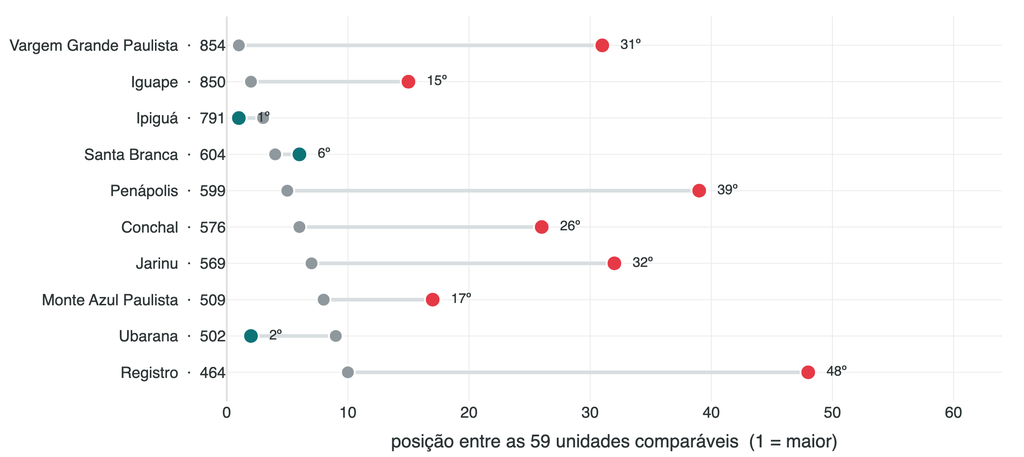

**Das 10 unidades que mais atenderam, 3 seguem no top 10** quando a leitura vira cobertura anualizada (pessoas ÷ população ÷ anos de operação). A exposição vai de 0,8 a 21 meses.

## A cobertura ainda mede geografia, não desempenho

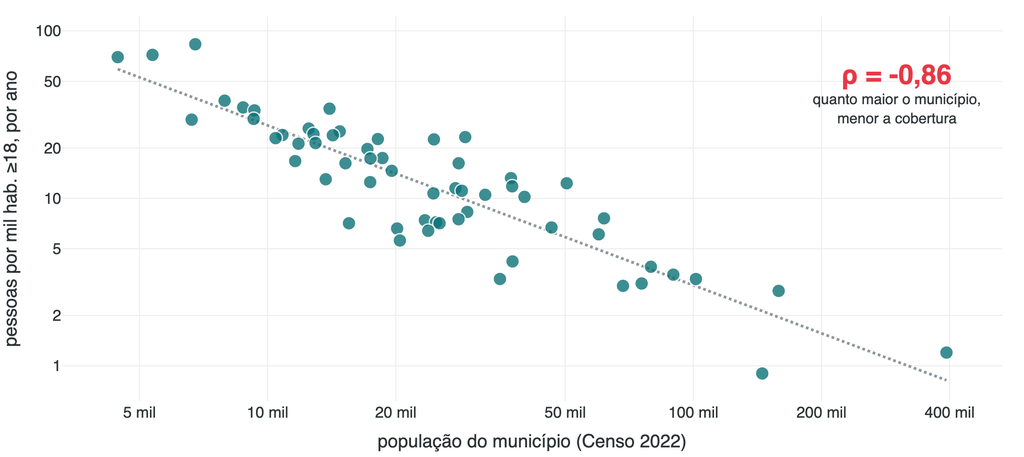

Uma UBS num município de 4 mil pessoas cobre uma fração do território que uma UBS em 400 mil não tem como cobrir.

**Duas rotas para descer o denominador — a primeira é nossa:** SISAB/e-Gestor (proposto na nossa apresentação de 06/07, público desde maio) e, refinando, a ficha de caracterização do PDI.

## Onde há discriminação real: retenção na APS

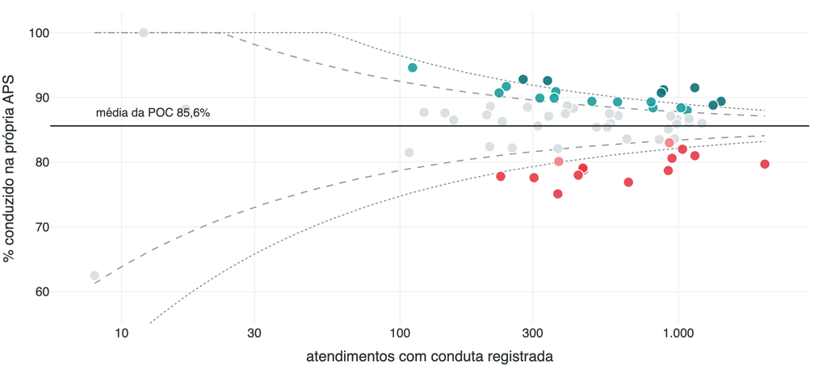

**33 das 67 unidades** saem do intervalo esperado para o seu volume; **16 continuam fora** ao corrigir para as 67 comparações.

Testar 67 unidades daria 3,4 “achados” por acaso — o excesso é muito maior que isso.

A média da POC pesada por atendimento é **85,6%** — o mesmo valor que ancorou o critério do T1, por caminho independente.

## O que caracteriza as melhores — e o que não

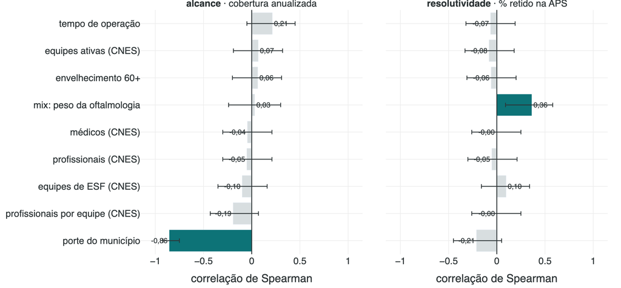

**Não detectamos associação entre a composição da equipe e a retenção na APS** (fatores CNES entre −0,08 e 0,10, todos com IC cruzando zero). **Não detectamos ≠ não existe:** com 59 unidades o intervalo ainda comporta efeito até 0,34. O único sinal é o mix de encaminhamento — **prática, não estrutura**.

## Volume e concentração de idosos não coincidem

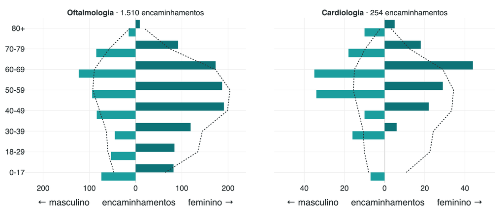

**Oftalmologia lidera o volume (1.510); cardiologia lidera a concentração etária: 51,2% dos seus encaminhamentos têm 60+, contra 32,9% em oftalmologia e 28,1% no conjunto.** A linha pontilhada é o perfil de todos os atendimentos, aplicado ao total de cada especialidade. *No painel, a pirâmide tem seletor: dá para percorrer as 18 especialidades ao vivo.*

## Onde replicar e onde investigar

| Unidade | Bruta | Padronizada | Atend. |
| --- | --- | --- | --- |
| ↑ **Guará** · PSF Jd Itapema | 91,5% | **90,6%** | 1.146 |
| ↑ **Atibaia** · USF Ana Nery | 91,2% | **89,7%** | 885 |
| ↑ **Cristais Paulista** · ESF Mirian M. | 92,6% | **92,1%** | 339 |
| ↓ **Piraju** · ESF São Pedro | 76,9% | **76,6%** | 662 |
| ↓ **Cajamar** · USF Manoel Inácio | 78,7% | **77,9%** | 920 |
| ↓ **São Manuel** · UBS I Padre Antonio | 75,1% | **78,5%** | 369 |

**Só entra quem é extremo nas duas leituras.** Comparar por percentual bruto confunde desempenho com **case-mix**: quem atende mais olhos encaminha mais por construção.

**O ajuste muda quem aparece.** Borborema sai de 8º para 42º ao padronizar — pelo bruto entraria na lista das melhores. O que difere lá é o perfil de condições, não a conduta.

*Padronização indireta por capítulo CIAP: quantos encaminhamentos seriam esperados se a unidade aplicasse a taxa da rede ao seu próprio mix. Reter é desejável **até certo ponto** — por isso “investigar”, não “corrigir”.*

## A rede dobrou e a mancha clareou

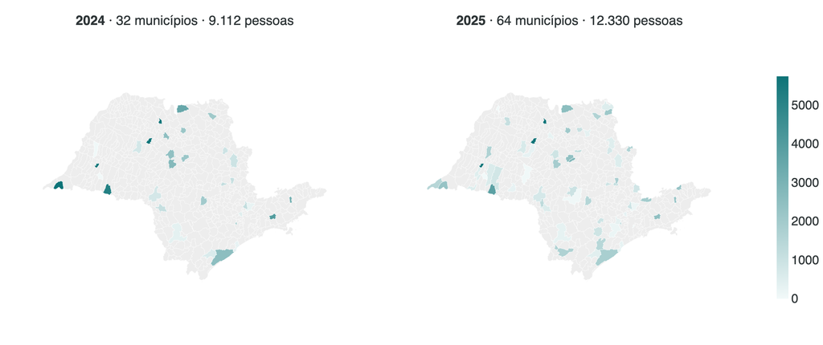

**Taxa mediana por município caiu de 1.824 para 932 por 100 mil.** Dos 31 municípios presentes nos dois anos, **27 recuaram**. O crescimento de 2024 para 2025 é **expansão da rede, não intensificação do uso** — as duas coisas têm implicações opostas para a expansão estadual.

## Critérios do re-run, fixados antes do dado

| # | Verificação | Critério |
| --- | --- | --- |
| 0 | **Contrato de entrada** | schema × dicionário · *drift* devolvido antes de ler |
| 1 | Completude por variável | não cai abaixo de 63 · 54 · 49 · 47% |
| 2-3 | **T1 robustez e discriminação** | **85,6 ± 3 p.p.** · 16 de 67 distinguíveis após correção |
| 4-5 | T3 gradiente e sinal de ouvidos | olhos acima das crônicas, intervalos que não se tocam |
| 6-7 | Perfil: denominador e eixos | ρ com o porte segue forte? eixos seguem independentes? |

**Cada linha é um teste automatizado.** Um critério definido depois de ver o resultado sempre pode ser ajustado para caber nele; fixado antes, ele pode dizer “não”.

## O que precisamos, e o que vem no C5-C6

**Pedidos ao PDI**

| Insumo | Para quê |
| --- | --- |
| **Ficha de caracterização** | adscrita declarada — **refina** o denominador do SISAB |
| Dicionários gold **TeleSAP** e **AME+Digital** | mesma data de corte da consolidação |
| Índices **SD e RT** do Mapeamento | desempenho × maturidade |

*Devolução: USF Jardim Maracá (Marília) está na base e não na planilha de controle.*

**Nosso lado**

- **TeleSAP entra agora** (S5 volume/conduta + S1 desempenho)
- Contrato de entrada antes do re-run
- Residência × território (CEP → município)
- ANS, SISAB e IPVS no perfil das unidades
- Fechar o T2 (população atendida)

## O que fica deste ciclo, em uma tela

**O que sabemos agora**

- **Encaminhamento**: olhos 69,7% × crônicas 11-14% · oftalmologia em 55 de 58 unidades
- **Quem é encaminhado**: cardiologia concentra idosos (51,2%), oftalmologia lidera volume
- **Desempenho**: 16 de 67 unidades fora do esperado após correção · média 85,6%
- **O que explica**: não detectamos efeito de estrutura (equipes, profissionais) — o poder não descarta efeito moderado
- **Crescimento**: expansão da rede, não intensificação do uso

**O que trava, e quem destrava**

- Denominador por unidade → **nós** (SISAB/e-Gestor) · ficha do PDI refina
- Destino do encaminhamento → **SES** (SIRESP)
- Parâmetro de referência → **área técnica**
- Custo e economia → **SES** (pergunta da expansão)
- ANS · SISAB · IPVS → **nós**, no C5/C6

**A pergunta de 03/06 tem resposta parcial e uma resposta negativa útil:** não detectamos efeito da estrutura registrada no CNES. Enquanto o denominador for municipal, “desempenho por unidade” continua sendo em boa parte geografia — e **descer esse denominador começa por nós**, pelo SISAB/e-Gestor, sem esperar a ficha.

### Obrigado

Bragatte, M.A.S · Bolsa PDI 2026 · TO 212.435

*os dois pedidos de 03/06 na mesa: encaminhamentos completos, e o perfil de unidades com o limite do denominador quantificado*